# Modeling Hospital Visit Demand Based on Health Insurance

Kurt Decker

2026-04-15

# Research Objective

The purpose of this analysis is to explore and quantify the effect of having private health insurance on the number of visits to the hospital.

```r
# Libraries ####
library(readxl)
library(skimr)
library(ggplot2)
library(tidyverse)
library(MASS)
library(gt)
library(corrplot)
```

```r
# Reading in the data ####
df = read_xlsx("Demand for Medical Care.xlsx")
```

# Data Exploration and Description

```r
# Skim ####
skim(df)
```

Data summary

| Name | df |
| --- | --- |
| Number of rows | 4406 |
| Number of columns | 19 |
| _______________________ |  |
| Column type frequency: |  |
| character | 9 |
| numeric | 10 |
| ________________________ |  |
| Group variables | None |

**Variable type: character**

| skim_variable | n_missing | complete_rate | min | max | empty | n_unique | whitespace |
| --- | --- | --- | --- | --- | --- | --- | --- |
| health | 0 | 1 | 4 | 9 | 0 | 3 | 0 |
| adl | 0 | 1 | 6 | 7 | 0 | 2 | 0 |
| region | 0 | 1 | 4 | 9 | 0 | 4 | 0 |
| afam | 0 | 1 | 2 | 3 | 0 | 2 | 0 |
| gender | 0 | 1 | 4 | 6 | 0 | 2 | 0 |
| married | 0 | 1 | 2 | 3 | 0 | 2 | 0 |
| employed | 0 | 1 | 2 | 3 | 0 | 2 | 0 |
| insurance | 0 | 1 | 2 | 3 | 0 | 2 | 0 |
| medicaid | 0 | 1 | 2 | 3 | 0 | 2 | 0 |

**Variable type: numeric**

| skim_variable | n_missing | complete_rate | mean | sd | p0 | p25 | p50 | p75 | p100 | hist |
| --- | --- | --- | --- | --- | --- | --- | --- | --- | --- | --- |
| visits | 0 | 1 | 5.77 | 6.76 | 0.00 | 1.00 | 4.0 | 8.00 | 89.00 | ▇▁▁▁▁ |
| nvisits | 0 | 1 | 1.62 | 5.32 | 0.00 | 0.00 | 0.0 | 1.00 | 104.00 | ▇▁▁▁▁ |
| ovisits | 0 | 1 | 0.75 | 3.65 | 0.00 | 0.00 | 0.0 | 0.00 | 141.00 | ▇▁▁▁▁ |
| novisits | 0 | 1 | 0.54 | 3.88 | 0.00 | 0.00 | 0.0 | 0.00 | 155.00 | ▇▁▁▁▁ |
| emergency | 0 | 1 | 0.26 | 0.70 | 0.00 | 0.00 | 0.0 | 0.00 | 12.00 | ▇▁▁▁▁ |
| hospital | 0 | 1 | 0.30 | 0.75 | 0.00 | 0.00 | 0.0 | 0.00 | 8.00 | ▇▁▁▁▁ |
| chronic | 0 | 1 | 1.54 | 1.35 | 0.00 | 1.00 | 1.0 | 2.00 | 8.00 | ▇▅▁▁▁ |
| age | 0 | 1 | 7.40 | 0.63 | 6.60 | 6.90 | 7.3 | 7.80 | 10.90 | ▇▅▁▁▁ |
| school | 0 | 1 | 10.29 | 3.74 | 0.00 | 8.00 | 11.0 | 12.00 | 18.00 | ▁▂▅▇▂ |
| income | 0 | 1 | 2.53 | 2.92 | -1.01 | 0.91 | 1.7 | 3.17 | 54.84 | ▇▁▁▁▁ |

```r
# Grouping by region and insurance ####
df %>% group_by(insurance) %>%
  summarise(mean_hospital = round(mean(hospital),2),
            sd_hospital = round(sd(hospital),2),
            zero_visits = sum(hospital == 0)) %>%
  gt()
```

| insurance | mean_hospital | sd_hospital | zero_visits |
| --- | --- | --- | --- |
| no | 0.31 | 0.72 | 775 |
| yes | 0.29 | 0.75 | 2766 |

```r
df %>% group_by(region) %>%
  summarise(mean_hospital = round(mean(hospital),2),
            sd_hospital = round(sd(hospital),2),
            zero_visits = round(sum(hospital == 0),2)) %>%
  gt()
```

| region | mean_hospital | sd_hospital | zero_visits |
| --- | --- | --- | --- |
| midwest | 0.30 | 0.79 | 931 |
| northeast | 0.27 | 0.65 | 679 |
| other | 0.30 | 0.76 | 1293 |
| west | 0.30 | 0.75 | 638 |

```r
df %>% group_by(employed) %>%
  summarise(mean_hospital = round(mean(hospital),2),
            sd_hospital = round(sd(hospital),2),
            zero_visits = sum(hospital == 0)) %>%
  gt()
```

| employed | mean_hospital | sd_hospital | zero_visits |
| --- | --- | --- | --- |
| no | 0.30 | 0.76 | 3159 |
| yes | 0.23 | 0.61 | 382 |

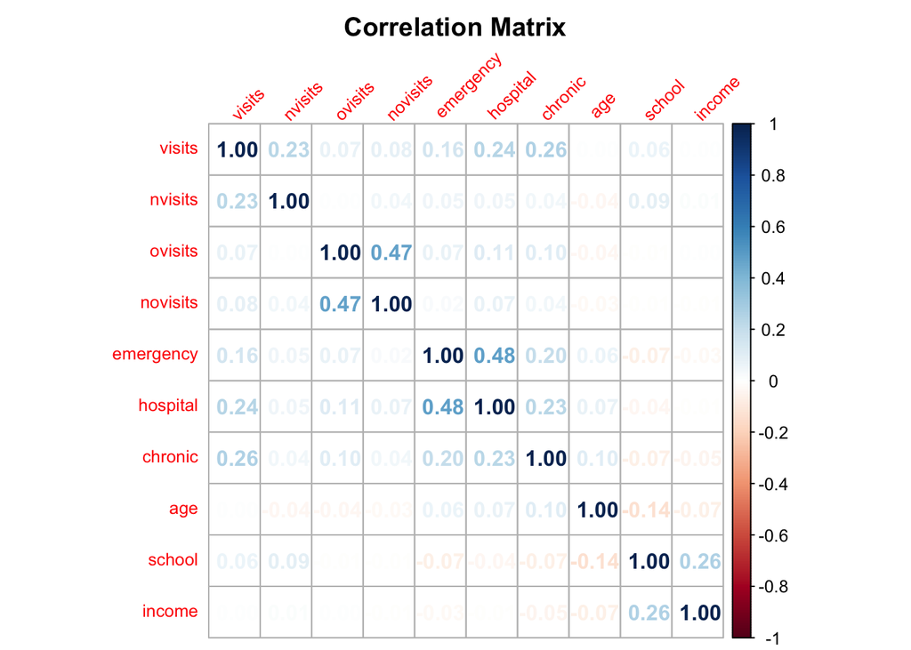

```r
# Correlation matrix of numeric predictors ####
cor_mat <- df %>%
  dplyr::select(where(is.numeric)) %>%
  cor() %>%
  round(2)

corrplot(cor_mat,
         method = "number",
         number.digits = 2,
         title = "Correlation Matrix",
         mar = c(0, 0, 2, 0),
         tl.cex = 0.8,
         tl.srt = 45)
```

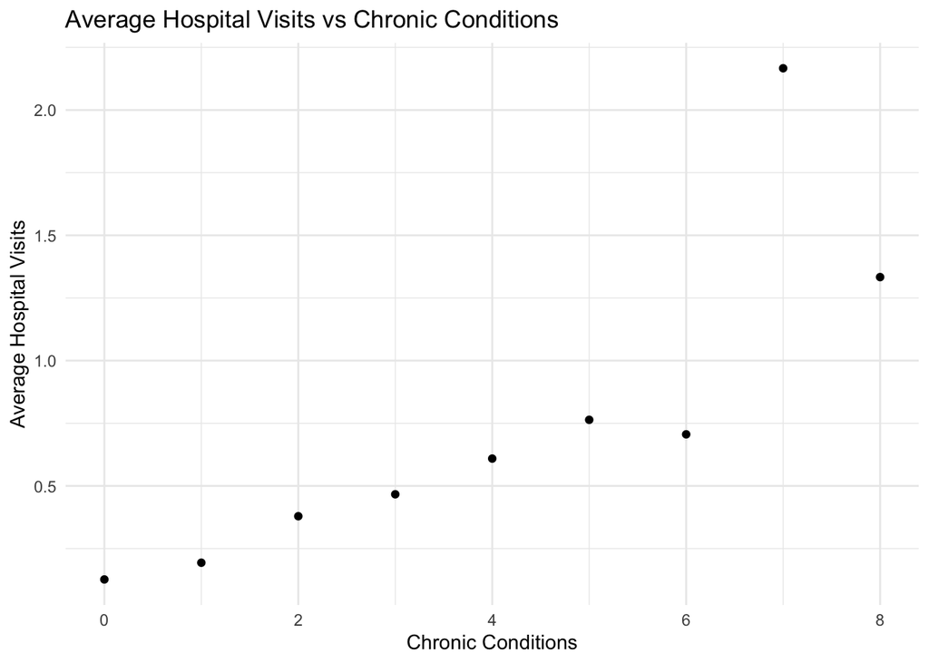

```r
# Graph of hospital visits vs chronic conditions ####
df %>%
  group_by(chronic) %>%
  summarise(mean_hospital = mean(hospital)) %>%
  ggplot(aes(x = chronic, y = mean_hospital)) +
  geom_point() +
  labs(title = "Average Hospital Visits vs Chronic Conditions",
       x = "Chronic Conditions",
       y = "Average Hospital Visits") +
  theme_minimal()
```

Above are some descriptive statistics for the variables in the data set. In this data set there are 4406 total people represented. There are a few important things to note. First, that there are a 3951 people who are unemployed represented in our data. Also, there are just 985 of the total 4406 who do not have insurance. And, there are 554 people who had poor health, 3509 who had average health, and 343 who had excellent health. For those with no health insurance, the average (standard deviation) number of hospital visits was 0.311 (0.716) while for those with health insurance it was 0.292 (0.755).

From the graph above, we can also see that there is a general positive trend between binned chronic conditions and average number of hospital visits. However, we also see that there are large amount of people who had zero hospital visits so the average number of hospital visits is very skewed.

# Analyzing the Effect of Insurance on Hospital Visits

To analyze the effect of insurance on hospital visits we’ll use a count regression model. Because we know that there are a large number of individuals who did not go to the hospital, a zero-inflated model may be best. Based on the exploratory tables above, and basic subject matter knowledge, the following predictors were chosen to be used in the modeling to try to answer our research question:

Insurance - If the person has private insurance.

Chronic - The number of chronic conditions the patient has.

Age - The age in decades of the patient.

## Poisson Count Model

```r
# Fitting a standard Poisson model ####
model_pois = glm(hospital ~ insurance + chronic + age,
                 family = poisson, data = df)
summary(model_pois)
```

```
##
## Call:
## glm(formula = hospital ~ insurance + chronic + age, family = poisson,
##     data = df)
##
## Coefficients:
##              Estimate Std. Error z value Pr(>|z|)
## (Intercept)  -3.41261    0.32160 -10.611  < 2e-16 ***
## insuranceyes  0.04384    0.06582   0.666    0.505
## chronic       0.33723    0.01660  20.317  < 2e-16 ***
## age           0.20333    0.04158   4.890 1.01e-06 ***
## ---
## Signif. codes:  0 '***' 0.001 '**' 0.01 '*' 0.05 '.' 0.1 ' ' 1
##
## (Dispersion parameter for poisson family taken to be 1)
##
##     Null deviance: 4662.5  on 4405  degrees of freedom
## Residual deviance: 4256.4  on 4402  degrees of freedom
## AIC: 6211
##
## Number of Fisher Scoring iterations: 6
```

From the Poisson model above, we see that both the number of chronic conditions and the age of the individual are significant predictors of hospital visits. Having private insurance is not though. Before proceeding, we’ll check for zero-inflation and overdispersion. If either are present, another model would be more appropriate.

```r
# Checking for overdispersion ####
mean(df$hospital)
```

```
## [1] 0.2959601
```

```r
var(df$hospital)
```

```
## [1] 0.5571097
```

One of the assumptions of Poisson regression is that the average of the response is equal to its variance. The average number of hospital visits in our data is approximately 0.3 with a variance of 0.56. This shows that we have overdispersion in our data set and we should use a negative binomial model rather than a Poisson model.

## Negative Binomial Count Model

```r
model_nb = glm.nb(hospital ~ insurance + chronic + age, data = df)
summary(model_nb)
```

```
##
## Call:
## glm.nb(formula = hospital ~ insurance + chronic + age, data = df,
##     init.theta = 0.513635978, link = log)
##
## Coefficients:
##              Estimate Std. Error z value Pr(>|z|)
## (Intercept)  -3.81088    0.42393  -8.989  < 2e-16 ***
## insuranceyes  0.03141    0.08623   0.364    0.716
## chronic       0.36639    0.02407  15.224  < 2e-16 ***
## age           0.25045    0.05501   4.553  5.3e-06 ***
## ---
## Signif. codes:  0 '***' 0.001 '**' 0.01 '*' 0.05 '.' 0.1 ' ' 1
##
## (Dispersion parameter for Negative Binomial(0.5136) family taken to be 1)
##
##     Null deviance: 2791.8  on 4405  degrees of freedom
## Residual deviance: 2533.0  on 4402  degrees of freedom
## AIC: 5786.1
##
## Number of Fisher Scoring iterations: 1
##
##
##               Theta:  0.5136
##           Std. Err.:  0.0447
##
##  2 x log-likelihood:  -5776.1440
```

The summary output shows that both the number of chronic conditions and age are significant predictors of hospital visits. Before proceeding though, we’ll also check for zero inflation since we already have evidence of a large number of individuals who did not go to the hospital.

```r
predicted_mu = predict(model_nb, type = "response")
theta = model_nb$theta

expected_zero = mean(dnbinom(0, mu = predicted_mu, size = theta)) *nrow(df)

observed_zero = sum(df$hospital == 0)

c(observed_zero, expected_zero)
```

```
## [1] 3541.000 3544.129
```

# Interpretation

Our final model, in an algebraic form, can represented as:
$$\log(\widehat{\text{Hospital}}) = -3.81 + 0.03 (\text{Insurance}) + 0.37
(\text{Chronic}) + 0.25 (\text{Age})$$

Where “Insurance” is an indicator variable equal to 1 if the individual has private insurance and 0 otherwise, “Chronic” is the number of chronic conditions the individual has, and “Age” is the person’s age (in decades).

```r
# incidence rate ratios and confidence intervals ####
round(exp(coef(model_nb)), 3)
```

```
##  (Intercept) insuranceyes      chronic          age
##        0.022        1.032        1.443        1.285
```

```r
round(exp(confint(model_nb)), 3)
```

```
##              2.5 % 97.5 %
## (Intercept)  0.010  0.051
## insuranceyes 0.872  1.223
## chronic      1.374  1.516
## age          1.152  1.432
```

The incidence rate ratio (95% confidence interval) associated with each of our predictors are:

Insurance : 1.032 (0.872, 1.223)

Chronic : 1.443 (1.374, 1.516)

Age: 1.285 (1.152, 1.432)

This incidence rate ratio for insurance suggests that those with private insurance are predicted to have roughly 3% more hospital visits than those without, but because the predictor was not statistically significant (our CI included 1) we can not say there is a statistical difference between the groups. However, for each additional chronic condition, individuals are predicted to have 44.3% (95% CI: 37.4%, 51.6%) more hospital visits. And an increase of 10 years in age is expected to increase hospital visits by 28.5% (95% CI: 15.2%, 43.2%).

# Considerations, Limitations, and Conclusion

It should be noted that selection of predictors could be significantly improved with more subject matter knowledge and expertise. Also, little information was available on the collection of this data set and therefore we should be cautious to apply results to a population. In this primary exploration of the data and research question, the entire data set was used to train the model. In the future, it may be more appropriate to subset the data and test it against a portion. However, with questions about the collection of the data, it would best to first focus attention of ensuring data quality.

In conclusion, the demand for hospital visits is most heavily effected by the number of chronic conditions an individual has and their age. After adjusting for these predictors, knowing if a person has private insurance does not show a significant association with hospital visits. Health insurance companies, hospitals, and doctors can expect, on average, a 44% increase in hospital visits for each additional chronic condition a person has. Additionally, a 10 year incrase in age is expected to result in almost 29% more hospital visits.